[Antonio Schettino](https://www.researchgate.net/profile/Antonio_Schettino2)

2017-03-09

In this project we will investigate the electrophysiological correlates of the combined processing of basic visual properties (i.e., size and contrast) and the emotional content of simple words.

```r
data.EEG.trial.all <- read.csv(here::here("EEG/pilot/data/pilot_trialEEG.csv"), header = TRUE) # load data

data.EEG.trial <- data.EEG.trial.all[data.EEG.trial.all$bin %in% c(1:8), ] # subset trials main experiment

data.EEG.trial$size <- # main effect of size
  revalue(
    factor(data.EEG.trial$bin),
    c(
      "1" = "large", "2" = "small", "3" = "large", "4" = "small",
      "5" = "large", "6" = "small", "7" = "large", "8" = "small"
    )
  )

data.EEG.trial$cont <- # main effect of contrast
  revalue(
    factor(data.EEG.trial$bin),
    c(
      "1" = "dark", "2" = "dark", "3" = "bright", "4" = "bright",
      "5" = "dark", "6" = "dark", "7" = "bright", "8" = "bright"
    )
  )

data.EEG.trial$emo <- # main effect of emotion
  revalue(
    factor(data.EEG.trial$bin),
    c(
      "1" = "negative", "2" = "negative", "3" = "negative", "4" = "negative",
      "5" = "neutral", "6" = "neutral", "7" = "neutral", "8" = "neutral"
    )
  )

data.EEG.trial$bin <- # recode bin variable
  revalue(
    factor(data.EEG.trial$bin),
    c(
      "1" = "negativeLargeDark", "2" = "negativeSmallDark", "3" = "negativeLargeBright", "4" = "negativeSmallBright",
      "5" = "neutralLargeDark", "6" = "neutralSmallDark", "7" = "neutralLargeBright", "8" = "neutralSmallBright"
    )
  )

data.EEG.trial <- within(data.EEG.trial, size <- relevel(size, ref = "large")) # reference size to large
data.EEG.trial <- within(data.EEG.trial, cont <- relevel(cont, ref = "dark")) # reference cont to dark
data.EEG.trial <- within(data.EEG.trial, emo <- relevel(emo, ref = "neutral")) # reference emo to neutral
```

The data we will use in this demo come from a pilot experiment (N = 3).

We will first focus on the ERP data of the main task.

# *MAIN TASK*

```r
# assess normality
ERPcomp <- factor(c("P1", "N1", "EPN", "LPP")) # ERP components

for (i in levels(ERPcomp)) { # loop through components

  for (j in levels(data.EEG.trial$bin)) { # loop through conditions

    tempdata <- data.EEG.trial[data.EEG.trial$bin == j, i] # subset current condition and ERP

    jpeg( # save as jpeg
      filename = here::here("EEG/pilot/graphs/normality", i, paste0(j, ".jpg")),
           width = 480,
      height = 480,
      units = "px",
      quality = 100)

    plotdist(tempdata, histo = TRUE, demp = TRUE) # empirical density and cumulative distribution

    dev.off()

  }

}
```

Density plots (not shown in the output) suggest that the normal distribution is a parsimonious approximate description of the data.

We will use linear mixed-effects models with random intercepts and fixed slopes. Models with random slopes have troubles converging, particularly on small datasets. The random factor is participants, although in the future we will include items (i.e., the individual words) as well.

# *P1*

```r
# summarize data
summary.data.EEG.trial <-
  summarySEwithin(
    data.EEG.trial,
    "P1",
    withinvars = c("size", "cont", "emo"),
    idvar = "participant"
    )

summary.data.EEG.trial
```

```
##    size   cont      emo   N      P1   sd    se    ci
## 1 large   dark  neutral 180  1.3679 3.39 0.253 0.499
## 2 large   dark negative 180  1.6303 3.42 0.255 0.503
## 3 large bright  neutral 179  1.2353 3.43 0.256 0.506
## 4 large bright negative 179  0.7387 3.56 0.266 0.526
## 5 small   dark  neutral 179  1.7784 3.34 0.250 0.493
## 6 small   dark negative 180  1.4122 3.36 0.251 0.495
## 7 small bright  neutral 178 -0.1328 3.60 0.270 0.533
## 8 small bright negative 179 -0.0957 3.29 0.246 0.485
```

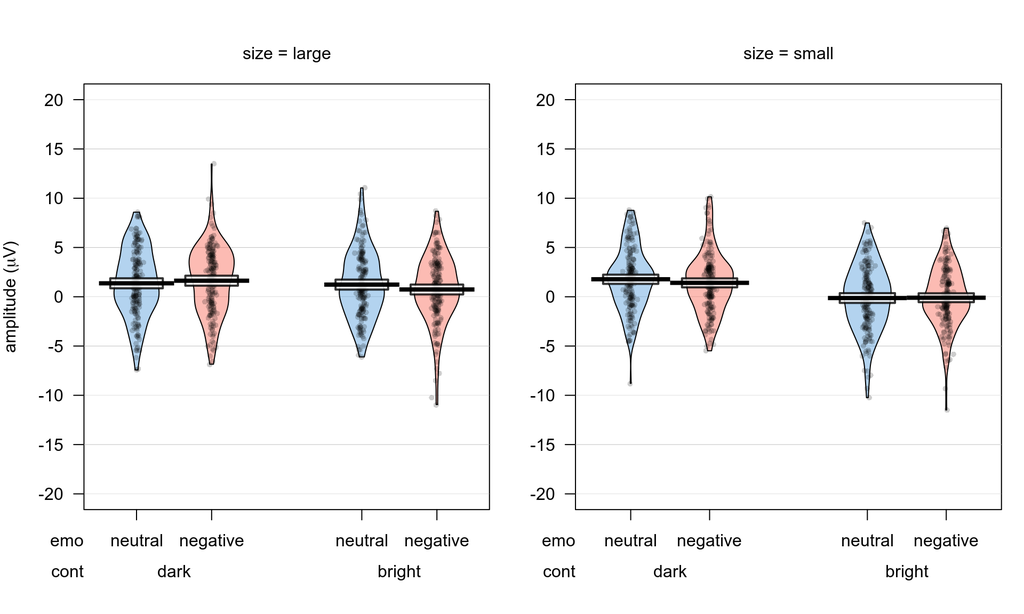

```r
# P1 graph
pirateplot(
  formula = P1 ~ emo + cont + size, # dependent~independent variables
  data = data.EEG.trial, # data frame
  main = "", # main title
  xlim = NULL, # x-axis: limits
  xlab = "", # x-axis: label
  ylim = c(-20, 20), # y-axis: limits
  ylab = expression(paste("amplitude (", mu, "V)")), # y-axis: label
  inf.method = "ci", # type of inference: 95% confidence intervals
  pal = "xmen" # color palette [see piratepal(palette="all")]
)
```

We will compute the following models:

1. null model
2. main effect of size
3. main effect of contrast
4. main effect of emotion
5. main effects of size and contrast
6. main effects of size and emotion
7. main effects of contrast and emotion
8. main effects of size, contrast, and emotion
9. size x contrast interaction
10. size x emotion interaction
11. contrast x emotion interaction
12. size x contrast x emotion interaction

We will then compare them all using the Bayesian Infomation Criterion (BIC).

```r
### null model
P1.null.lmer.fixedslope <- lmer(P1 ~ 1 + (1 | participant), data = data.EEG.trial) # model
summary.P1.null.lmer.fixedslope <- summary(P1.null.lmer.fixedslope) # summary model

### main effect of size
P1.size.lmer.fixedslope <- lmer(P1 ~ size + (1 | participant), data = data.EEG.trial) # model
summary.P1.size.lmer.fixedslope <- summary(P1.size.lmer.fixedslope) # summary model
pvalue.P1.size.lmer.fixedslope <- Anova(P1.size.lmer.fixedslope) # calculate p-values
# contrasts
P1.size.lmer.fixedslope.contr <- lsmeans(P1.size.lmer.fixedslope, pairwise ~ size, adjust = "tukey")
# P1.size.lmer.fixedslope.contr$contrasts

### main effect of contrast
P1.cont.lmer.fixedslope <- lmer(P1 ~ cont + (1 | participant), data = data.EEG.trial) # model
summary.P1.cont.lmer.fixedslope <- summary(P1.cont.lmer.fixedslope) # summary model
pvalue.P1.cont.lmer.fixedslope <- Anova(P1.cont.lmer.fixedslope) # calculate p-values
# contrasts
P1.cont.lmer.fixedslope.contr <- lsmeans(P1.cont.lmer.fixedslope, pairwise ~ cont, adjust = "tukey")
# P1.cont.lmer.fixedslope.contr$contrasts

### main effect of emotion
P1.emo.lmer.fixedslope <- lmer(P1 ~ emo + (1 | participant), data = data.EEG.trial) # model
summary.P1.emo.lmer.fixedslope <- summary(P1.emo.lmer.fixedslope) # summary model
pvalue.P1.emo.lmer.fixedslope <- Anova(P1.emo.lmer.fixedslope) # calculate p-values
# contrasts
P1.emo.lmer.fixedslope.contr <- lsmeans(P1.emo.lmer.fixedslope, pairwise ~ emo, adjust = "tukey")
# P1.emo.lmer.fixedslope.contr$contrasts

### main effects of size and contrast
P1.sizecontmaineff.lmer.fixedslope <- lmer(P1 ~ size + cont + (1 | participant), data = data.EEG.trial) # model
summary.P1.sizecontmaineff.lmer.fixedslope <- summary(P1.sizecontmaineff.lmer.fixedslope) # summary model
pvalue.P1.sizecontmaineff.lmer.fixedslope <- Anova(P1.sizecontmaineff.lmer.fixedslope) # calculate p-values
# contrasts
P1.sizecontmaineff.lmer.fixedslope.contr <- lsmeans(P1.sizecontmaineff.lmer.fixedslope, pairwise ~ size + cont, adjust = "tukey")
# P1.sizecontmaineff.lmer.fixedslope.contr$contrasts

### main effects of size and emotion
P1.sizeemomaineff.lmer.fixedslope <- lmer(P1 ~ size + emo + (1 | participant), data = data.EEG.trial) # model
summary.P1.sizeemomaineff.lmer.fixedslope <- summary(P1.sizeemomaineff.lmer.fixedslope) # summary model
pvalue.P1.sizeemomaineff.lmer.fixedslope <- Anova(P1.sizeemomaineff.lmer.fixedslope) # calculate p-values
# contrasts
P1.sizeemomaineff.lmer.fixedslope.contr <- lsmeans(P1.sizeemomaineff.lmer.fixedslope, pairwise ~ size + emo, adjust = "tukey")
# P1.sizeemomaineff.lmer.fixedslope.contr$contrasts

### main effects of contrast and emotion
P1.contemomaineff.lmer.fixedslope <- lmer(P1 ~ cont + emo + (1 | participant), data = data.EEG.trial) # model
summary.P1.contemomaineff.lmer.fixedslope <- summary(P1.contemomaineff.lmer.fixedslope) # summary model
pvalue.P1.contemomaineff.lmer.fixedslope <- Anova(P1.contemomaineff.lmer.fixedslope) # calculate p-values
# contrasts
P1.contemomaineff.lmer.fixedslope.contr <- lsmeans(P1.contemomaineff.lmer.fixedslope, pairwise ~ cont + emo, adjust = "tukey")
# P1.contemomaineff.lmer.fixedslope.contr$contrasts

### main effects of size, contrast, and emotion
P1.allmaineff.lmer.fixedslope <- lmer(P1 ~ size + cont + emo + (1 | participant), data = data.EEG.trial) # model
summary.P1.allmaineff.lmer.fixedslope <- summary(P1.allmaineff.lmer.fixedslope) # summary model
pvalue.P1.allmaineff.lmer.fixedslope <- Anova(P1.allmaineff.lmer.fixedslope) # calculate p-values
# contrasts
P1.allmaineff.lmer.fixedslope.contr <- lsmeans(P1.allmaineff.lmer.fixedslope, pairwise ~ size + cont + emo, adjust = "tukey")
# P1.allmaineff.lmer.fixedslope.contr$contrasts

### size x contrast interaction
P1.sizecont.lmer.fixedslope <- lmer(P1 ~ size * cont + (1 | participant), data = data.EEG.trial) # model
summary.P1.sizecont.lmer.fixedslope <- summary(P1.sizecont.lmer.fixedslope) # summary model
pvalue.P1.sizecont.lmer.fixedslope <- Anova(P1.sizecont.lmer.fixedslope) # calculate p-values
# contrasts
P1.sizecont.lmer.fixedslope.contr <- lsmeans(P1.sizecont.lmer.fixedslope, pairwise ~ size * cont, adjust = "tukey")
# P1.sizecont.lmer.fixedslope.contr$contrasts

### size x emotion interaction
P1.sizeemo.lmer.fixedslope <- lmer(P1 ~ size * emo + (1 | participant), data = data.EEG.trial) # model
summary.P1.sizeemo.lmer.fixedslope <- summary(P1.sizeemo.lmer.fixedslope) # summary model
pvalue.P1.sizeemo.lmer.fixedslope <- Anova(P1.sizeemo.lmer.fixedslope) # calculate p-values
# contrasts
P1.sizeemo.lmer.fixedslope.contr <- lsmeans(P1.sizeemo.lmer.fixedslope, pairwise ~ size * emo, adjust = "tukey")
# P1.sizeemo.lmer.fixedslope.contr$contrasts

### contrast x emotion interaction
P1.contemo.lmer.fixedslope <- lmer(P1 ~ cont * emo + (1 | participant), data = data.EEG.trial) # model
summary.P1.contemo.lmer.fixedslope <- summary(P1.contemo.lmer.fixedslope) # summary model
pvalue.P1.contemo.lmer.fixedslope <- Anova(P1.contemo.lmer.fixedslope) # calculate p-values
# contrasts
P1.contemo.lmer.fixedslope.contr <- lsmeans(P1.contemo.lmer.fixedslope, pairwise ~ cont * emo, adjust = "tukey")
# P1.contemo.lmer.fixedslope.contr$contrasts

### size x contrast x emotion interaction
P1.sizecontemo.lmer.fixedslope <- lmer(P1 ~ size * cont * emo + (1 | participant), data = data.EEG.trial) # model
summary.P1.sizecontemo.lmer.fixedslope <- summary(P1.sizecontemo.lmer.fixedslope) # summary model
pvalue.P1.sizecontemo.lmer.fixedslope <- Anova(P1.sizecontemo.lmer.fixedslope) # calculate p-values
# contrasts
P1.sizecontemo.lmer.fixedslope.contr <- lsmeans(P1.sizecontemo.lmer.fixedslope, pairwise ~ size * cont * emo, adjust = "tukey")
# P1.sizecontemo.lmer.fixedslope.contr$contrasts

### model comparison via Bayesian Infomation Criterion (BIC)
P1.lmer.fixedslope.BIC <- BIC(P1.null.lmer.fixedslope, P1.size.lmer.fixedslope, P1.cont.lmer.fixedslope, P1.emo.lmer.fixedslope, P1.sizecontmaineff.lmer.fixedslope, P1.sizeemomaineff.lmer.fixedslope, P1.contemomaineff.lmer.fixedslope, P1.allmaineff.lmer.fixedslope, P1.sizecont.lmer.fixedslope, P1.sizeemo.lmer.fixedslope, P1.contemo.lmer.fixedslope, P1.sizecontemo.lmer.fixedslope)

# summary
compare.P1.lmer.fixedslope <- data.frame(model = c("null", "size", "contrast", "emotion", "size+contrast", "size+emotion", "contrast+emotion", "size+contrast+emotion", "size*contrast", "size*emotion", "contrast*emotion", "size*contrast*emotion"), BIC = P1.lmer.fixedslope.BIC$BIC)
compare.P1.lmer.fixedslope <- compare.P1.lmer.fixedslope[with(compare.P1.lmer.fixedslope, order(BIC)), ] # sort according to BIC (in ascending order)
compare.P1.lmer.fixedslope
```

```
##                    model  BIC
## 9          size*contrast 7466
## 3               contrast 7470
## 5          size+contrast 7471
## 7       contrast+emotion 7479
## 8  size+contrast+emotion 7479
## 11      contrast*emotion 7486
## 12 size*contrast*emotion 7492
## 1                   null 7503
## 2                   size 7504
## 4                emotion 7511
## 6           size+emotion 7512
## 10          size*emotion 7520
```

The model to prefer should be size*contrast.

# *N1*

```r
# summarize data
summary.data.EEG.trial <-
  summarySEwithin(
    data.EEG.trial,
    "N1",
    withinvars = c("size", "cont", "emo"),
    idvar = "participant"
  )

summary.data.EEG.trial
```

```
##    size   cont      emo   N    N1   sd    se    ci
## 1 large   dark  neutral 180 -3.65 3.66 0.273 0.538
## 2 large   dark negative 180 -3.20 3.93 0.293 0.578
## 3 large bright  neutral 179 -2.72 4.02 0.300 0.592
## 4 large bright negative 179 -2.30 4.22 0.316 0.623
## 5 small   dark  neutral 179 -3.44 3.85 0.288 0.567
## 6 small   dark negative 180 -3.65 3.73 0.278 0.549
## 7 small bright  neutral 178 -0.72 3.91 0.293 0.579
## 8 small bright negative 179 -1.03 3.94 0.295 0.582
```

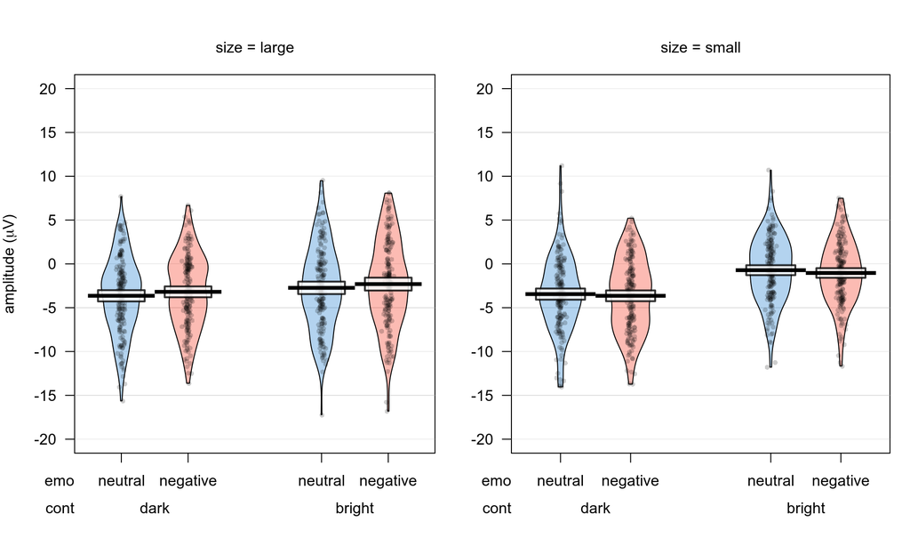

```r
# N1 graph
pirateplot(
  formula = N1 ~ emo + cont + size, # dependent~independent variables
  data = data.EEG.trial, # data frame
  main = "", # main title
  xlim = NULL, # x-axis: limits
  xlab = "", # x-axis: label
  ylim = c(-20, 20), # y-axis: limits
  ylab = expression(paste("amplitude (", mu, "V)")), # y-axis: label
  inf.method = "ci", # type of inference: 95% confidence intervals
  pal = "xmen" # color palette [see piratepal(palette="all")]
)
```

```r
### null model
N1.null.lmer.fixedslope <- lmer(N1 ~ 1 + (1 | participant), data = data.EEG.trial) # model
summary.N1.null.lmer.fixedslope <- summary(N1.null.lmer.fixedslope) # summary model

### main effect of size
N1.size.lmer.fixedslope <- lmer(N1 ~ size + (1 | participant), data = data.EEG.trial) # model
summary.N1.size.lmer.fixedslope <- summary(N1.size.lmer.fixedslope) # summary model
pvalue.N1.size.lmer.fixedslope <- Anova(N1.size.lmer.fixedslope) # calculate p-values
# contrasts
N1.size.lmer.fixedslope.contr <- lsmeans(N1.size.lmer.fixedslope, pairwise ~ size, adjust = "tukey")
# N1.size.lmer.fixedslope.contr$contrasts

### main effect of contrast
N1.cont.lmer.fixedslope <- lmer(N1 ~ cont + (1 | participant), data = data.EEG.trial) # model
summary.N1.cont.lmer.fixedslope <- summary(N1.cont.lmer.fixedslope) # summary model
pvalue.N1.cont.lmer.fixedslope <- Anova(N1.cont.lmer.fixedslope) # calculate p-values
# contrasts
N1.cont.lmer.fixedslope.contr <- lsmeans(N1.cont.lmer.fixedslope, pairwise ~ cont, adjust = "tukey")
# N1.cont.lmer.fixedslope.contr$contrasts

### main effect of emotion
N1.emo.lmer.fixedslope <- lmer(N1 ~ emo + (1 | participant), data = data.EEG.trial) # model
summary.N1.emo.lmer.fixedslope <- summary(N1.emo.lmer.fixedslope) # summary model
pvalue.N1.emo.lmer.fixedslope <- Anova(N1.emo.lmer.fixedslope) # calculate p-values
# contrasts
N1.emo.lmer.fixedslope.contr <- lsmeans(N1.emo.lmer.fixedslope, pairwise ~ emo, adjust = "tukey")
# N1.emo.lmer.fixedslope.contr$contrasts

### main effects of size and contrast
N1.sizecontmaineff.lmer.fixedslope <- lmer(N1 ~ size + cont + (1 | participant), data = data.EEG.trial) # model
summary.N1.sizecontmaineff.lmer.fixedslope <- summary(N1.sizecontmaineff.lmer.fixedslope) # summary model
pvalue.N1.sizecontmaineff.lmer.fixedslope <- Anova(N1.sizecontmaineff.lmer.fixedslope) # calculate p-values
# contrasts
N1.sizecontmaineff.lmer.fixedslope.contr <- lsmeans(N1.sizecontmaineff.lmer.fixedslope, pairwise ~ size + cont, adjust = "tukey")
# N1.sizecontmaineff.lmer.fixedslope.contr$contrasts

### main effects of size and emotion
N1.sizeemomaineff.lmer.fixedslope <- lmer(N1 ~ size + emo + (1 | participant), data = data.EEG.trial) # model
summary.N1.sizeemomaineff.lmer.fixedslope <- summary(N1.sizeemomaineff.lmer.fixedslope) # summary model
pvalue.N1.sizeemomaineff.lmer.fixedslope <- Anova(N1.sizeemomaineff.lmer.fixedslope) # calculate p-values
# contrasts
N1.sizeemomaineff.lmer.fixedslope.contr <- lsmeans(N1.sizeemomaineff.lmer.fixedslope, pairwise ~ size + emo, adjust = "tukey")
# N1.sizeemomaineff.lmer.fixedslope.contr$contrasts

### main effects of contrast and emotion
N1.contemomaineff.lmer.fixedslope <- lmer(N1 ~ cont + emo + (1 | participant), data = data.EEG.trial) # model
summary.N1.contemomaineff.lmer.fixedslope <- summary(N1.contemomaineff.lmer.fixedslope) # summary model
pvalue.N1.contemomaineff.lmer.fixedslope <- Anova(N1.contemomaineff.lmer.fixedslope) # calculate p-values
# contrasts
N1.contemomaineff.lmer.fixedslope.contr <- lsmeans(N1.contemomaineff.lmer.fixedslope, pairwise ~ cont + emo, adjust = "tukey")
# N1.contemomaineff.lmer.fixedslope.contr$contrasts

### main effects of size, contrast, and emotion
N1.allmaineff.lmer.fixedslope <- lmer(N1 ~ size + cont + emo + (1 | participant), data = data.EEG.trial) # model
summary.N1.allmaineff.lmer.fixedslope <- summary(N1.allmaineff.lmer.fixedslope) # summary model
pvalue.N1.allmaineff.lmer.fixedslope <- Anova(N1.allmaineff.lmer.fixedslope) # calculate p-values
# contrasts
N1.allmaineff.lmer.fixedslope.contr <- lsmeans(N1.allmaineff.lmer.fixedslope, pairwise ~ size + cont + emo, adjust = "tukey")
# N1.allmaineff.lmer.fixedslope.contr$contrasts

### size x contrast interaction
N1.sizecont.lmer.fixedslope <- lmer(N1 ~ size * cont + (1 | participant), data = data.EEG.trial) # model
summary.N1.sizecont.lmer.fixedslope <- summary(N1.sizecont.lmer.fixedslope) # summary model
pvalue.N1.sizecont.lmer.fixedslope <- Anova(N1.sizecont.lmer.fixedslope) # calculate p-values
# contrasts
N1.sizecont.lmer.fixedslope.contr <- lsmeans(N1.sizecont.lmer.fixedslope, pairwise ~ size * cont, adjust = "tukey")
# N1.sizecont.lmer.fixedslope.contr$contrasts

### size x emotion interaction
N1.sizeemo.lmer.fixedslope <- lmer(N1 ~ size * emo + (1 | participant), data = data.EEG.trial) # model
summary.N1.sizeemo.lmer.fixedslope <- summary(N1.sizeemo.lmer.fixedslope) # summary model
pvalue.N1.sizeemo.lmer.fixedslope <- Anova(N1.sizeemo.lmer.fixedslope) # calculate p-values
# contrasts
N1.sizeemo.lmer.fixedslope.contr <- lsmeans(N1.sizeemo.lmer.fixedslope, pairwise ~ size * emo, adjust = "tukey")
# N1.sizeemo.lmer.fixedslope.contr$contrasts

### contrast x emotion interaction
N1.contemo.lmer.fixedslope <- lmer(N1 ~ cont * emo + (1 | participant), data = data.EEG.trial) # model
summary.N1.contemo.lmer.fixedslope <- summary(N1.contemo.lmer.fixedslope) # summary model
pvalue.N1.contemo.lmer.fixedslope <- Anova(N1.contemo.lmer.fixedslope) # calculate p-values
# contrasts
N1.contemo.lmer.fixedslope.contr <- lsmeans(N1.contemo.lmer.fixedslope, pairwise ~ cont * emo, adjust = "tukey")
# N1.contemo.lmer.fixedslope.contr$contrasts

### size x contrast x emotion interaction
N1.sizecontemo.lmer.fixedslope <- lmer(N1 ~ size * cont * emo + (1 | participant), data = data.EEG.trial) # model
summary.N1.sizecontemo.lmer.fixedslope <- summary(N1.sizecontemo.lmer.fixedslope) # summary model
pvalue.N1.sizecontemo.lmer.fixedslope <- Anova(N1.sizecontemo.lmer.fixedslope) # calculate p-values
# contrasts
N1.sizecontemo.lmer.fixedslope.contr <- lsmeans(N1.sizecontemo.lmer.fixedslope, pairwise ~ size * cont * emo, adjust = "tukey")
# N1.sizecontemo.lmer.fixedslope.contr$contrasts

### model comparison via Bayesian Infomation Criterion (BIC)
N1.lmer.fixedslope.BIC <- BIC(N1.null.lmer.fixedslope, N1.size.lmer.fixedslope, N1.cont.lmer.fixedslope, N1.emo.lmer.fixedslope, N1.sizecontmaineff.lmer.fixedslope, N1.sizeemomaineff.lmer.fixedslope, N1.contemomaineff.lmer.fixedslope, N1.allmaineff.lmer.fixedslope, N1.sizecont.lmer.fixedslope, N1.sizeemo.lmer.fixedslope, N1.contemo.lmer.fixedslope, N1.sizecontemo.lmer.fixedslope)

# summary
compare.N1.lmer.fixedslope <- data.frame(model = c("null", "size", "contrast", "emotion", "size+contrast", "size+emotion", "contrast+emotion", "size+contrast+emotion", "size*contrast", "size*emotion", "contrast*emotion", "size*contrast*emotion"), BIC = N1.lmer.fixedslope.BIC$BIC)
compare.N1.lmer.fixedslope <- compare.N1.lmer.fixedslope[with(compare.N1.lmer.fixedslope, order(BIC)), ] # sort according to BIC (in ascending order)
compare.N1.lmer.fixedslope
```

```
##                    model  BIC
## 9          size*contrast 7848
## 5          size+contrast 7861
## 3               contrast 7867
## 8  size+contrast+emotion 7870
## 12 size*contrast*emotion 7874
## 7       contrast+emotion 7876
## 11      contrast*emotion 7883
## 2                   size 7935
## 1                   null 7940
## 6           size+emotion 7943
## 10          size*emotion 7947
## 4                emotion 7949
```

The model to prefer should be size*contrast.

# *EPN*

```r
# summarize data
summary.data.EEG.trial <-
  summarySEwithin(
    data.EEG.trial,
    "EPN",
    withinvars = c("size", "cont", "emo"),
    idvar = "participant"
    )
summary.data.EEG.trial
```

```
##    size   cont      emo   N   EPN   sd    se    ci
## 1 large   dark  neutral 180 -1.39 3.71 0.277 0.546
## 2 large   dark negative 180 -1.06 3.68 0.275 0.542
## 3 large bright  neutral 179 -2.69 4.10 0.307 0.605
## 4 large bright negative 179 -2.46 3.73 0.279 0.550
## 5 small   dark  neutral 179 -1.16 4.08 0.305 0.602
## 6 small   dark negative 180 -1.84 3.53 0.263 0.519
## 7 small bright  neutral 178 -1.41 4.11 0.308 0.607
## 8 small bright negative 179 -1.77 3.85 0.288 0.568
```

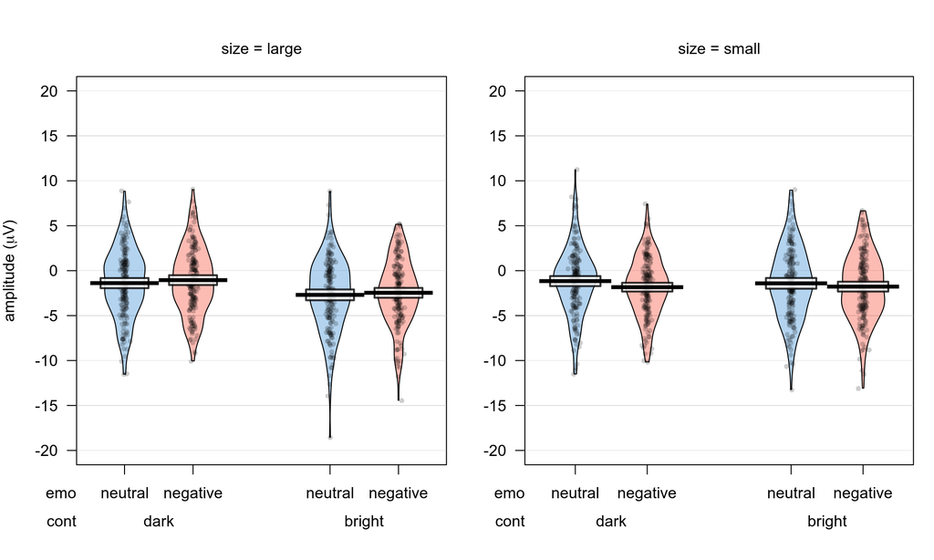

```r
# EPN graph
pirateplot(
  formula = EPN ~ emo + cont + size, # dependent~independent variables
  data = data.EEG.trial, # data frame
  main = "", # main title
  xlim = NULL, # x-axis: limits
  xlab = "", # x-axis: label
  ylim = c(-20, 20), # y-axis: limits
  ylab = expression(paste("amplitude (", mu, "V)")), # y-axis: label
  inf.method = "ci", # type of inference: 95% confidence intervals
  pal = "xmen" # color palette [see piratepal(palette="all")]
)
```

```r
### null model
EPN.null.lmer.fixedslope <- lmer(EPN ~ 1 + (1 | participant), data = data.EEG.trial) # model
summary.EPN.null.lmer.fixedslope <- summary(EPN.null.lmer.fixedslope) # summary model

### main effect of size
EPN.size.lmer.fixedslope <- lmer(EPN ~ size + (1 | participant), data = data.EEG.trial) # model
summary.EPN.size.lmer.fixedslope <- summary(EPN.size.lmer.fixedslope) # summary model
pvalue.EPN.size.lmer.fixedslope <- Anova(EPN.size.lmer.fixedslope) # calculate p-values
# contrasts
EPN.size.lmer.fixedslope.contr <- lsmeans(EPN.size.lmer.fixedslope, pairwise ~ size, adjust = "tukey")
# EPN.size.lmer.fixedslope.contr$contrasts

### main effect of contrast
EPN.cont.lmer.fixedslope <- lmer(EPN ~ cont + (1 | participant), data = data.EEG.trial) # model
summary.EPN.cont.lmer.fixedslope <- summary(EPN.cont.lmer.fixedslope) # summary model
pvalue.EPN.cont.lmer.fixedslope <- Anova(EPN.cont.lmer.fixedslope) # calculate p-values
# contrasts
EPN.cont.lmer.fixedslope.contr <- lsmeans(EPN.cont.lmer.fixedslope, pairwise ~ cont, adjust = "tukey")
# EPN.cont.lmer.fixedslope.contr$contrasts

### main effect of emotion
EPN.emo.lmer.fixedslope <- lmer(EPN ~ emo + (1 | participant), data = data.EEG.trial) # model
summary.EPN.emo.lmer.fixedslope <- summary(EPN.emo.lmer.fixedslope) # summary model
pvalue.EPN.emo.lmer.fixedslope <- Anova(EPN.emo.lmer.fixedslope) # calculate p-values
# contrasts
EPN.emo.lmer.fixedslope.contr <- lsmeans(EPN.emo.lmer.fixedslope, pairwise ~ emo, adjust = "tukey")
# EPN.emo.lmer.fixedslope.contr$contrasts

### main effects of size and contrast
EPN.sizecontmaineff.lmer.fixedslope <- lmer(EPN ~ size + cont + (1 | participant), data = data.EEG.trial) # model
summary.EPN.sizecontmaineff.lmer.fixedslope <- summary(EPN.sizecontmaineff.lmer.fixedslope) # summary model
pvalue.EPN.sizecontmaineff.lmer.fixedslope <- Anova(EPN.sizecontmaineff.lmer.fixedslope) # calculate p-values
# contrasts
EPN.sizecontmaineff.lmer.fixedslope.contr <- lsmeans(EPN.sizecontmaineff.lmer.fixedslope, pairwise ~ size + cont, adjust = "tukey")
# EPN.sizecontmaineff.lmer.fixedslope.contr$contrasts

### main effects of size and emotion
EPN.sizeemomaineff.lmer.fixedslope <- lmer(EPN ~ size + emo + (1 | participant), data = data.EEG.trial) # model
summary.EPN.sizeemomaineff.lmer.fixedslope <- summary(EPN.sizeemomaineff.lmer.fixedslope) # summary model
pvalue.EPN.sizeemomaineff.lmer.fixedslope <- Anova(EPN.sizeemomaineff.lmer.fixedslope) # calculate p-values
# contrasts
EPN.sizeemomaineff.lmer.fixedslope.contr <- lsmeans(EPN.sizeemomaineff.lmer.fixedslope, pairwise ~ size + emo, adjust = "tukey")
# EPN.sizeemomaineff.lmer.fixedslope.contr$contrasts

### main effects of contrast and emotion
EPN.contemomaineff.lmer.fixedslope <- lmer(EPN ~ cont + emo + (1 | participant), data = data.EEG.trial) # model
summary.EPN.contemomaineff.lmer.fixedslope <- summary(EPN.contemomaineff.lmer.fixedslope) # summary model
pvalue.EPN.contemomaineff.lmer.fixedslope <- Anova(EPN.contemomaineff.lmer.fixedslope) # calculate p-values
# contrasts
EPN.contemomaineff.lmer.fixedslope.contr <- lsmeans(EPN.contemomaineff.lmer.fixedslope, pairwise ~ cont + emo, adjust = "tukey")
# EPN.contemomaineff.lmer.fixedslope.contr$contrasts

### main effects of size, contrast, and emotion
EPN.allmaineff.lmer.fixedslope <- lmer(EPN ~ size + cont + emo + (1 | participant), data = data.EEG.trial) # model
summary.EPN.allmaineff.lmer.fixedslope <- summary(EPN.allmaineff.lmer.fixedslope) # summary model
pvalue.EPN.allmaineff.lmer.fixedslope <- Anova(EPN.allmaineff.lmer.fixedslope) # calculate p-values
# contrasts
EPN.allmaineff.lmer.fixedslope.contr <- lsmeans(EPN.allmaineff.lmer.fixedslope, pairwise ~ size + cont + emo, adjust = "tukey")
# EPN.allmaineff.lmer.fixedslope.contr$contrasts

### size x contrast interaction
EPN.sizecont.lmer.fixedslope <- lmer(EPN ~ size * cont + (1 | participant), data = data.EEG.trial) # model
summary.EPN.sizecont.lmer.fixedslope <- summary(EPN.sizecont.lmer.fixedslope) # summary model
pvalue.EPN.sizecont.lmer.fixedslope <- Anova(EPN.sizecont.lmer.fixedslope) # calculate p-values
# contrasts
EPN.sizecont.lmer.fixedslope.contr <- lsmeans(EPN.sizecont.lmer.fixedslope, pairwise ~ size * cont, adjust = "tukey")
# EPN.sizecont.lmer.fixedslope.contr$contrasts

### size x emotion interaction
EPN.sizeemo.lmer.fixedslope <- lmer(EPN ~ size * emo + (1 | participant), data = data.EEG.trial) # model
summary.EPN.sizeemo.lmer.fixedslope <- summary(EPN.sizeemo.lmer.fixedslope) # summary model
pvalue.EPN.sizeemo.lmer.fixedslope <- Anova(EPN.sizeemo.lmer.fixedslope) # calculate p-values
# contrasts
EPN.sizeemo.lmer.fixedslope.contr <- lsmeans(EPN.sizeemo.lmer.fixedslope, pairwise ~ size * emo, adjust = "tukey")
# EPN.sizeemo.lmer.fixedslope.contr$contrasts

### contrast x emotion interaction
EPN.contemo.lmer.fixedslope <- lmer(EPN ~ cont * emo + (1 | participant), data = data.EEG.trial) # model
summary.EPN.contemo.lmer.fixedslope <- summary(EPN.contemo.lmer.fixedslope) # summary model
pvalue.EPN.contemo.lmer.fixedslope <- Anova(EPN.contemo.lmer.fixedslope) # calculate p-values
# contrasts
EPN.contemo.lmer.fixedslope.contr <- lsmeans(EPN.contemo.lmer.fixedslope, pairwise ~ cont * emo, adjust = "tukey")
# EPN.contemo.lmer.fixedslope.contr$contrasts

### size x contrast x emotion interaction
EPN.sizecontemo.lmer.fixedslope <- lmer(EPN ~ size * cont * emo + (1 | participant), data = data.EEG.trial) # model
summary.EPN.sizecontemo.lmer.fixedslope <- summary(EPN.sizecontemo.lmer.fixedslope) # summary model
pvalue.EPN.sizecontemo.lmer.fixedslope <- Anova(EPN.sizecontemo.lmer.fixedslope) # calculate p-values
# contrasts
EPN.sizecontemo.lmer.fixedslope.contr <- lsmeans(EPN.sizecontemo.lmer.fixedslope, pairwise ~ size * cont * emo, adjust = "tukey")
# EPN.sizecontemo.lmer.fixedslope.contr$contrasts

### model comparison via Bayesian Infomation Criterion (BIC)
EPN.lmer.fixedslope.BIC <- BIC(EPN.null.lmer.fixedslope, EPN.size.lmer.fixedslope, EPN.cont.lmer.fixedslope, EPN.emo.lmer.fixedslope, EPN.sizecontmaineff.lmer.fixedslope, EPN.sizeemomaineff.lmer.fixedslope, EPN.contemomaineff.lmer.fixedslope, EPN.allmaineff.lmer.fixedslope, EPN.sizecont.lmer.fixedslope, EPN.sizeemo.lmer.fixedslope, EPN.contemo.lmer.fixedslope, EPN.sizecontemo.lmer.fixedslope)

# summary
compare.EPN.lmer.fixedslope <- data.frame(model = c("null", "size", "contrast", "emotion", "size+contrast", "size+emotion", "contrast+emotion", "size+contrast+emotion", "size*contrast", "size*emotion", "contrast*emotion", "size*contrast*emotion"), BIC = EPN.lmer.fixedslope.BIC$BIC)
compare.EPN.lmer.fixedslope <- compare.EPN.lmer.fixedslope[with(compare.EPN.lmer.fixedslope, order(BIC)), ] # sort according to BIC (in ascending order)
compare.EPN.lmer.fixedslope
```

```
##                    model  BIC
## 3               contrast 7803
## 9          size*contrast 7805
## 5          size+contrast 7808
## 1                   null 7808
## 7       contrast+emotion 7811
## 2                   size 7814
## 8  size+contrast+emotion 7817
## 4                emotion 7817
## 11      contrast*emotion 7818
## 6           size+emotion 7822
## 10          size*emotion 7825
## 12 size*contrast*emotion 7829
```

The model to prefer should be contrast.

# *LPP*

```r
# summarize data
summary.data.EEG.trial <-
  summarySEwithin(
    data.EEG.trial,
    "LPP",
    withinvars = c("size", "cont", "emo"),
    idvar = "participant"
  )

summary.data.EEG.trial
```

```
##    size   cont      emo   N   LPP   sd    se    ci
## 1 large   dark  neutral 180 0.389 2.54 0.189 0.374
## 2 large   dark negative 180 0.884 2.26 0.168 0.332
## 3 large bright  neutral 179 0.748 2.12 0.158 0.313
## 4 large bright negative 179 1.154 2.50 0.187 0.368
## 5 small   dark  neutral 179 0.403 2.48 0.185 0.365
## 6 small   dark negative 180 0.248 2.43 0.181 0.358
## 7 small bright  neutral 178 0.807 2.53 0.190 0.374
## 8 small bright negative 179 0.743 2.39 0.179 0.353
```

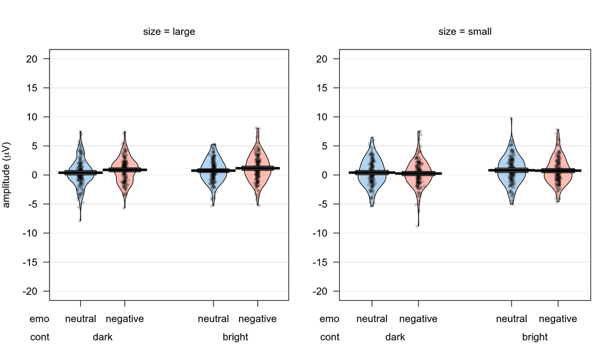

```r
# LPP graph
pirateplot(
  formula = LPP ~ emo + cont + size, # dependent~independent variables
  data = data.EEG.trial, # data frame
  main = "", # main title
  xlim = NULL, # x-axis: limits
  xlab = "", # x-axis: label
  ylim = c(-20, 20), # y-axis: limits
  ylab = expression(paste("amplitude (", mu, "V)")), # y-axis: label
  inf.method = "ci", # type of inference: 95% confidence intervals
  pal = "xmen" # color palette [see piratepal(palette="all")]
)
```

```r
### null model
LPP.null.lmer.fixedslope <- lmer(LPP ~ 1 + (1 | participant), data = data.EEG.trial) # model
summary.LPP.null.lmer.fixedslope <- summary(LPP.null.lmer.fixedslope) # summary model

### main effect of size
LPP.size.lmer.fixedslope <- lmer(LPP ~ size + (1 | participant), data = data.EEG.trial) # model
summary.LPP.size.lmer.fixedslope <- summary(LPP.size.lmer.fixedslope) # summary model
pvalue.LPP.size.lmer.fixedslope <- Anova(LPP.size.lmer.fixedslope) # calculate p-values
# contrasts
LPP.size.lmer.fixedslope.contr <- lsmeans(LPP.size.lmer.fixedslope, pairwise ~ size, adjust = "tukey")
# LPP.size.lmer.fixedslope.contr$contrasts

### main effect of contrast
LPP.cont.lmer.fixedslope <- lmer(LPP ~ cont + (1 | participant), data = data.EEG.trial) # model
summary.LPP.cont.lmer.fixedslope <- summary(LPP.cont.lmer.fixedslope) # summary model
pvalue.LPP.cont.lmer.fixedslope <- Anova(LPP.cont.lmer.fixedslope) # calculate p-values
# contrasts
LPP.cont.lmer.fixedslope.contr <- lsmeans(LPP.cont.lmer.fixedslope, pairwise ~ cont, adjust = "tukey")
# LPP.cont.lmer.fixedslope.contr$contrasts

### main effect of emotion
LPP.emo.lmer.fixedslope <- lmer(LPP ~ emo + (1 | participant), data = data.EEG.trial) # model
summary.LPP.emo.lmer.fixedslope <- summary(LPP.emo.lmer.fixedslope) # summary model
pvalue.LPP.emo.lmer.fixedslope <- Anova(LPP.emo.lmer.fixedslope) # calculate p-values
# contrasts
LPP.emo.lmer.fixedslope.contr <- lsmeans(LPP.emo.lmer.fixedslope, pairwise ~ emo, adjust = "tukey")
# LPP.emo.lmer.fixedslope.contr$contrasts

### main effects of size and contrast
LPP.sizecontmaineff.lmer.fixedslope <- lmer(LPP ~ size + cont + (1 | participant), data = data.EEG.trial) # model
summary.LPP.sizecontmaineff.lmer.fixedslope <- summary(LPP.sizecontmaineff.lmer.fixedslope) # summary model
pvalue.LPP.sizecontmaineff.lmer.fixedslope <- Anova(LPP.sizecontmaineff.lmer.fixedslope) # calculate p-values
# contrasts
LPP.sizecontmaineff.lmer.fixedslope.contr <- lsmeans(LPP.sizecontmaineff.lmer.fixedslope, pairwise ~ size + cont, adjust = "tukey")
# LPP.sizecontmaineff.lmer.fixedslope.contr$contrasts

### main effects of size and emotion
LPP.sizeemomaineff.lmer.fixedslope <- lmer(LPP ~ size + emo + (1 | participant), data = data.EEG.trial) # model
summary.LPP.sizeemomaineff.lmer.fixedslope <- summary(LPP.sizeemomaineff.lmer.fixedslope) # summary model
pvalue.LPP.sizeemomaineff.lmer.fixedslope <- Anova(LPP.sizeemomaineff.lmer.fixedslope) # calculate p-values
# contrasts
LPP.sizeemomaineff.lmer.fixedslope.contr <- lsmeans(LPP.sizeemomaineff.lmer.fixedslope, pairwise ~ size + emo, adjust = "tukey")
# LPP.sizeemomaineff.lmer.fixedslope.contr$contrasts

### main effects of contrast and emotion
LPP.contemomaineff.lmer.fixedslope <- lmer(LPP ~ cont + emo + (1 | participant), data = data.EEG.trial) # model
summary.LPP.contemomaineff.lmer.fixedslope <- summary(LPP.contemomaineff.lmer.fixedslope) # summary model
pvalue.LPP.contemomaineff.lmer.fixedslope <- Anova(LPP.contemomaineff.lmer.fixedslope) # calculate p-values
# contrasts
LPP.contemomaineff.lmer.fixedslope.contr <- lsmeans(LPP.contemomaineff.lmer.fixedslope, pairwise ~ cont + emo, adjust = "tukey")
# LPP.contemomaineff.lmer.fixedslope.contr$contrasts

### main effects of size, contrast, and emotion
LPP.allmaineff.lmer.fixedslope <- lmer(LPP ~ size + cont + emo + (1 | participant), data = data.EEG.trial) # model
summary.LPP.allmaineff.lmer.fixedslope <- summary(LPP.allmaineff.lmer.fixedslope) # summary model
pvalue.LPP.allmaineff.lmer.fixedslope <- Anova(LPP.allmaineff.lmer.fixedslope) # calculate p-values
# contrasts
LPP.allmaineff.lmer.fixedslope.contr <- lsmeans(LPP.allmaineff.lmer.fixedslope, pairwise ~ size + cont + emo, adjust = "tukey")
# LPP.allmaineff.lmer.fixedslope.contr$contrasts

### size x contrast interaction
LPP.sizecont.lmer.fixedslope <- lmer(LPP ~ size * cont + (1 | participant), data = data.EEG.trial) # model
summary.LPP.sizecont.lmer.fixedslope <- summary(LPP.sizecont.lmer.fixedslope) # summary model
pvalue.LPP.sizecont.lmer.fixedslope <- Anova(LPP.sizecont.lmer.fixedslope) # calculate p-values
# contrasts
LPP.sizecont.lmer.fixedslope.contr <- lsmeans(LPP.sizecont.lmer.fixedslope, pairwise ~ size * cont, adjust = "tukey")
# LPP.sizecont.lmer.fixedslope.contr$contrasts

### size x emotion interaction
LPP.sizeemo.lmer.fixedslope <- lmer(LPP ~ size * emo + (1 | participant), data = data.EEG.trial) # model
summary.LPP.sizeemo.lmer.fixedslope <- summary(LPP.sizeemo.lmer.fixedslope) # summary model
pvalue.LPP.sizeemo.lmer.fixedslope <- Anova(LPP.sizeemo.lmer.fixedslope) # calculate p-values
# contrasts
LPP.sizeemo.lmer.fixedslope.contr <- lsmeans(LPP.sizeemo.lmer.fixedslope, pairwise ~ size * emo, adjust = "tukey")
# LPP.sizeemo.lmer.fixedslope.contr$contrasts

### contrast x emotion interaction
LPP.contemo.lmer.fixedslope <- lmer(LPP ~ cont * emo + (1 | participant), data = data.EEG.trial) # model
summary.LPP.contemo.lmer.fixedslope <- summary(LPP.contemo.lmer.fixedslope) # summary model
pvalue.LPP.contemo.lmer.fixedslope <- Anova(LPP.contemo.lmer.fixedslope) # calculate p-values
# contrasts
LPP.contemo.lmer.fixedslope.contr <- lsmeans(LPP.contemo.lmer.fixedslope, pairwise ~ cont * emo, adjust = "tukey")
# LPP.contemo.lmer.fixedslope.contr$contrasts

### size x contrast x emotion interaction
LPP.sizecontemo.lmer.fixedslope <- lmer(LPP ~ size * cont * emo + (1 | participant), data = data.EEG.trial) # model
summary.LPP.sizecontemo.lmer.fixedslope <- summary(LPP.sizecontemo.lmer.fixedslope) # summary model
pvalue.LPP.sizecontemo.lmer.fixedslope <- Anova(LPP.sizecontemo.lmer.fixedslope) # calculate p-values
# contrasts
LPP.sizecontemo.lmer.fixedslope.contr <- lsmeans(LPP.sizecontemo.lmer.fixedslope, pairwise ~ size * cont * emo, adjust = "tukey")
# LPP.sizecontemo.lmer.fixedslope.contr$contrasts

### model comparison via Bayesian Infomation Criterion (BIC)
LPP.lmer.fixedslope.BIC <- BIC(LPP.null.lmer.fixedslope, LPP.size.lmer.fixedslope, LPP.cont.lmer.fixedslope, LPP.emo.lmer.fixedslope, LPP.sizecontmaineff.lmer.fixedslope, LPP.sizeemomaineff.lmer.fixedslope, LPP.contemomaineff.lmer.fixedslope, LPP.allmaineff.lmer.fixedslope, LPP.sizecont.lmer.fixedslope, LPP.sizeemo.lmer.fixedslope, LPP.contemo.lmer.fixedslope, LPP.sizecontemo.lmer.fixedslope)

# summary
compare.LPP.lmer.fixedslope <- data.frame(model = c("null", "size", "contrast", "emotion", "size+contrast", "size+emotion", "contrast+emotion", "size+contrast+emotion", "size*contrast", "size*emotion", "contrast*emotion", "size*contrast*emotion"), BIC = LPP.lmer.fixedslope.BIC$BIC)
compare.LPP.lmer.fixedslope <- compare.LPP.lmer.fixedslope[with(compare.LPP.lmer.fixedslope, order(BIC)), ] # sort according to BIC (in ascending order)
compare.LPP.lmer.fixedslope
```

```
##                    model  BIC
## 3               contrast 6445
## 1                   null 6446
## 5          size+contrast 6451
## 2                   size 6451
## 7       contrast+emotion 6453
## 4                emotion 6453
## 8  size+contrast+emotion 6458
## 9          size*contrast 6459
## 6           size+emotion 6459
## 11      contrast*emotion 6461
## 10          size*emotion 6462
## 12 size*contrast*emotion 6484
```

The model to prefer should be contrast.